# Point Clustering

Applied Machine Learning in Economics

I am curious to see if we use clustering on a high-level occupation with various demographic and economic variables with two clusters if we the algorithm will separate by gender (the gender gap is huge in upper-level occupations). We are going to specifically look at Chief Executives and Public Administrators from the 2000 Census. You can look at the IPUMS website for the codebook. Before we get into it, let’s wrangle some data!

# Wrangling and Cleaning

Here is the code chunk so you can copy and paste it.

```r
library(tidyverse)
library(data.table) # You need this, 1.4gb dataset
set.seed(490)

usa = fread('C:/Users/johnj/Documents/Data/Applied ML ECON490/workshop data/usa/usa_00024.csv')

names(usa) = names(usa) %>% tolower
head(usa)

# Trimming the dataset first so manipulations take less time
nrow(usa)
usa = usa %>%
  filter(empstat == 1 &    # Employed
           wkswork1 >= 40 & # Wokerd at least 40 weeks last year
           uhrswork >= 30 & # Usually works at least 30 hours
           workedyr == 3 & # Worked last year
           incwage != 9999999 & # wage not missing
           citypop != 99999 & # city population not missing
           hhincome != 9999999 ) # HH income not missing
nrow(usa)
head(usa)

# We are going to look at chief executive and public administrator occupations
usa = filter(usa, occ1990 == 4)
nrow(usa)

# creating some variables
usa = usa %>%
  mutate(city_pop = citypop*100,
         children = (nchild > 0)*1,
         female = sex - 1,
         married = (marst %in% c(1:3))*1,
         black = (race == 2)*1,
         asian = (race %in% c(3:6))*1,
         educ = educ) # This is "close" to years of schooling, so we will leave it alone
```

## Creating Features

We are simply going to use `model.matrix()` with a `formula` to produce the features. However, to do so we need to make a faux y variable in the `formula` so `model.matrix()` is happy. We are going to use a log transformation, so we will also remove troublesome observations.

```r
usa = filter(usa, incwage != 0 & trantime != 0 & city_pop != 0)
f = rep(1, nrow(usa)) ~ educ + wkswork1 + uhrswork + log(incwage) + log(trantime) + log(city_pop) + children + female + married + black + asian - 1

x = model.matrix(f, usa)
head(x)
```

```
##   educ wkswork1 uhrswork log(incwage) log(trantime) log(city_pop) children
## 1   11       52       70     12.59134      2.302585      12.06451        0
## 2   11       50       40     11.15625      2.995732      12.06451        1
## 3   11       52       40     11.22524      3.401197      12.06451        0
## 4   11       52       60     11.69525      5.105945      12.06451        1
## 5    8       52       45     11.75194      2.302585      12.06451        1
## 6   11       52       50     11.38509      1.386294      12.06451        0
##   female married black asian
## 1      0       1     0     0
## 2      0       1     0     0
## 3      1       0     0     0
## 4      0       1     0     0
## 5      0       1     0     0
## 6      0       1     0     0
```

Let’s see if we can visually detect any differences by gender in a figure of usual hours worked versus income where the color will be assigned by stereotypical, gender-norm enforcing colors.

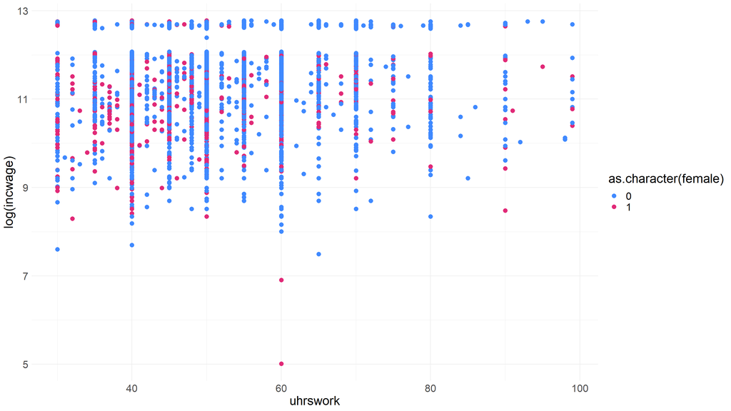

```r
ggplot(usa, aes(x = uhrswork, y = log(incwage), color = as.character(female))) +
  geom_point(size = 3) +
  scale_color_manual(values = c('#3F89FF','#E12977')) +
  theme_minimal() +
  theme(text = element_text(size = 20))
```

Maybe? Definitely look at the row of top coded incomes. It appears bluer than the average of the figure.

# K-Means Clustering

Remember that for clustering, it is in general a good idea to standardize the variables. This way each variable gets equal weight. Although, you may find yourself in a situation where you want to give extra weight to specific values. We do not different weights here because we want the clustering to arise organically.

`kmeans` has the arguments for `k` and `nstart`. `k` is the name of the game. `nstart` is the number of times the algorithm will restart with random assignments in search for the global optimum. It will on output the model with the smallest Euclidian distance.

```r
sx = scale(x)
clust = kmeans(sx, 2, nstart = 20) # k=2 with 20 different random starts

names(clust)
```

```
## [1] "cluster"      "centers"      "totss"        "withinss"     "tot.withinss"
## [6] "betweenss"    "size"         "iter"         "ifault"
```

```r
head(clust$cluster)
```

```
## 1 2 3 4 5 6
## 2 2 1 2 2 2
```

Now we can compare the assigned groups in two ways.

1. Unconditional assignments on other features via `t.test()`
2. Conditional assignments on all features via `lm()`

```r
# Creating a data.frame for ease in comparison
df = bind_cols(y = clust$cluster - 1, sx)
```

## Unconditional Comparisons

So, let’s try some t tests.

```r
t.test(female ~ y, data = df)
```

```
##
##  Welch Two Sample t-test
##
## data:  female by y
## t = 36.981, df = 3043, p-value < 2.2e-16
## alternative hypothesis: true difference in means is not equal to 0
## 95 percent confidence interval:
##  0.941618 1.047057
## sample estimates:
## mean in group 0 mean in group 1
##       0.6682837      -0.3260538
```

```r
t.test(`log(incwage)` ~ y, data = df)
```

```
##
##  Welch Two Sample t-test
##
## data:  log(incwage) by y
## t = -12.971, df = 4617.1, p-value < 2.2e-16
## alternative hypothesis: true difference in means is not equal to 0
## 95 percent confidence interval:
##  -0.3732503 -0.2752357
## sample estimates:
## mean in group 0 mean in group 1
##      -0.2179203       0.1063227
```

Why is `log(incwage)` wrapped in `` " `` " ``?

```r
names(df)
```

```
##  [1] "y"             "educ"          "wkswork1"      "uhrswork"
##  [5] "log(incwage)"  "log(trantime)" "log(city_pop)" "children"
##  [9] "female"        "married"       "black"         "asian"
```

That’s why.

## Conditional Comparisons

Remember that in a regression, all estimates are conditional on the other variables in the model. So, let’s give our good ol’ friend the LPM a go.

```r
lm(y ~ . - 1, data = df) %>% summary
```

```
##
## Call:
## lm(formula = y ~ . - 1, data = df)
##
## Residuals:
##     Min      1Q  Median      3Q     Max
## -0.1630  0.6081  0.6489  0.7964  1.3879
##
## Coefficients:
##                   Estimate Std. Error t value Pr(>|t|)
## educ             0.0069708  0.0085859   0.812    0.417
## wkswork1         0.0094125  0.0084157   1.118    0.263
## uhrswork        -0.0026652  0.0084750  -0.314    0.753
## `log(incwage)`   0.0129575  0.0087871   1.475    0.140
## `log(trantime)` -0.0013342  0.0084631  -0.158    0.875
## `log(city_pop)` -0.0095807  0.0085274  -1.124    0.261
## children         0.0796263  0.0089629   8.884   <2e-16 ***
## female          -0.1333076  0.0086700 -15.376   <2e-16 ***
## married          0.3377214  0.0091752  36.808   <2e-16 ***
## black           -0.0009009  0.0083879  -0.107    0.914
## asian            0.0039933  0.0084392   0.473    0.636
## ---
## Signif. codes:  0 '***' 0.001 '**' 0.01 '*' 0.05 '.' 0.1 ' ' 1
##
## Residual standard error: 0.7 on 7058 degrees of freedom
## Multiple R-squared:  0.2721, Adjusted R-squared:  0.271
## F-statistic: 239.9 on 11 and 7058 DF,  p-value: < 2.2e-16
```

Well, it looks like `group == 1` is primarily married men with children. The F statistic tells us that these groupings are very statistically different from one another.

## Different Feature Scaling

Let’s try not using transformations of our variables.

```r
f = rep(1, nrow(usa)) ~ educ + wkswork1 + uhrswork + incwage + trantime + city_pop + children + female + married + black + asian - 1
x = model.matrix(f, usa)
sx = scale(x)
df = bind_cols(y = clust$cluster - 1, sx)
clust = kmeans(sx, 2, nstart = 20)
lm(y ~ . - 1, data = df) %>% summary
```

```
##
## Call:
## lm(formula = y ~ . - 1, data = df)
##
## Residuals:
##     Min      1Q  Median      3Q     Max
## -0.1891  0.6033  0.6488  0.7968  1.3944
##
## Coefficients:
##           Estimate Std. Error t value Pr(>|t|)
## educ      0.007360   0.008517   0.864    0.388
## wkswork1  0.009865   0.008402   1.174    0.240
## uhrswork -0.002734   0.008471  -0.323    0.747
## incwage   0.012852   0.008704   1.477    0.140
## trantime -0.001151   0.008463  -0.136    0.892
## city_pop -0.010066   0.008544  -1.178    0.239
## children  0.079913   0.008958   8.921   <2e-16 ***
## female   -0.133187   0.008677 -15.350   <2e-16 ***
## married   0.337773   0.009170  36.834   <2e-16 ***
## black    -0.001073   0.008385  -0.128    0.898
## asian     0.004080   0.008442   0.483    0.629
## ---
## Signif. codes:  0 '***' 0.001 '**' 0.01 '*' 0.05 '.' 0.1 ' ' 1
##
## Residual standard error: 0.7 on 7058 degrees of freedom
## Multiple R-squared:  0.2721, Adjusted R-squared:  0.271
## F-statistic: 239.9 on 11 and 7058 DF,  p-value: < 2.2e-16
```

And how about not scaling or transforming our variables.

```r
f = rep(1, nrow(usa)) ~ educ + wkswork1 + uhrswork + incwage + trantime + city_pop + children + female + married + black + asian - 1
x = model.matrix(f, usa)
df = bind_cols(y = clust$cluster - 1, x)
clust = kmeans(sx, 2, nstart = 20)
lm(y ~ . - 1, data = df) %>% summary
```

```
##
## Call:
## lm(formula = y ~ . - 1, data = df)
##
## Residuals:
##      Min       1Q   Median       3Q      Max
## -0.99348 -0.00044 -0.00007  0.00044  0.00647
##
## Coefficients:
##            Estimate Std. Error  t value Pr(>|t|)
## educ     -7.297e-05  7.406e-05   -0.985  0.32450
## wkswork1  4.983e-05  1.901e-05    2.621  0.00878 **
## uhrswork -1.680e-05  1.361e-05   -1.235  0.21685
## incwage   2.056e-10  1.413e-09    0.145  0.88436
## trantime -1.882e-05  6.876e-06   -2.737  0.00622 **
## city_pop -1.105e-10  5.649e-11   -1.957  0.05040 .
## children  4.032e-04  3.054e-04    1.320  0.18680
## female   -6.425e-04  3.538e-04   -1.816  0.06943 .
## married   9.994e-01  3.521e-04 2838.164  < 2e-16 ***
## black    -3.356e-03  7.129e-04   -4.708 2.54e-06 ***
## asian     1.742e-04  6.068e-04    0.287  0.77407
## ---
## Signif. codes:  0 '***' 0.001 '**' 0.01 '*' 0.05 '.' 0.1 ' ' 1
##
## Residual standard error: 0.01186 on 7058 degrees of freedom
## Multiple R-squared:  0.9998, Adjusted R-squared:  0.9998
## F-statistic: 3.356e+06 on 11 and 7058 DF,  p-value: < 2.2e-16
```

Well, there you go.

# Hierarchical Clustering

We have two choices:

1. Dissimilarity Measure
   1. Euclidean distance
   2. Correlation-based distance
2. Linkage measure
   1. Average
   2. Single (minimal)
   3. Complete (maximal)

The correlation-based distance is in general a better idea in *this* setting, because we have many variables that are zero or one. But, we will start off with the distance measure. Note that we are going to be using the standardized, but not transformed features.

## Average Linkage

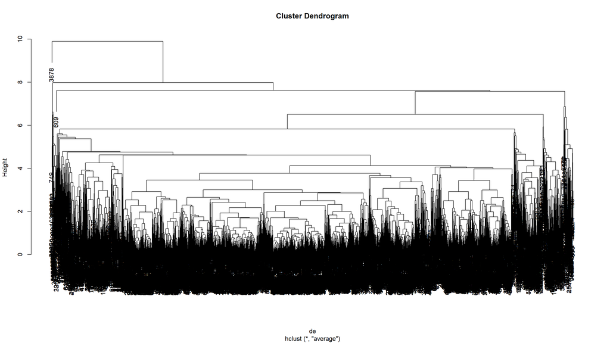

```r
de = dist(sx)

hc_avg = hclust(de, method = 'average')
plot(hc_avg)
```

It looks like we are getting pretty messy below a distance of 6, so do a split to obtain 5 branches.

```r
hc_avg_trim = cutree(hc_avg, 5)
table(hc_avg_trim)
```

```
## hc_avg_trim
##    1    2    3    4    5
## 6875   62  130    1    1
```

It looks like we have some observations that are dissimilar to the others. This may be a useful tool to identify “outlier” observations. We could discard them if we are truly trying to identify clusters of similar observations.

```r
which(hc_avg_trim == 4)
```

```
## 609
## 609
```

```r
which(hc_avg_trim == 5)
```

```
## 3878
## 3878
```

But, since we are demonstrating implementation, we can leave them there.

## Single Linkage

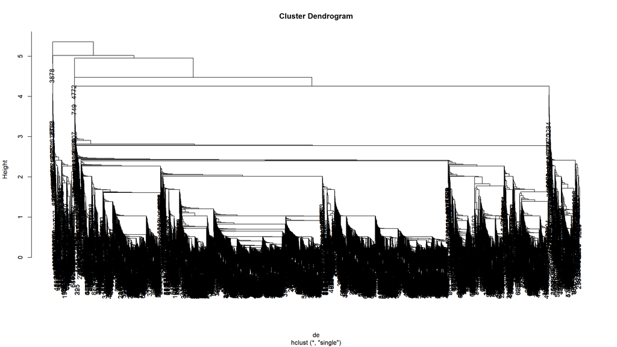

```r
hc_sngl = hclust(de, method = 'single')
plot(hc_sngl)
```

## Complete Linkage

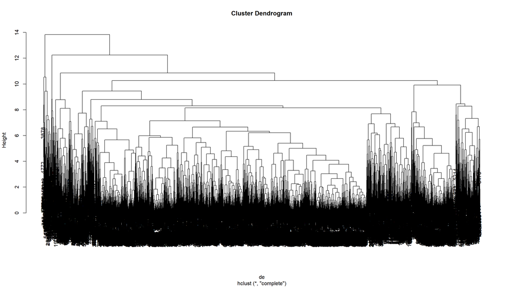

```r
plot(hclust(de, method = 'complete'))
```

Okay, that observation 3878 is showing up in all three. I normally would move on, but I am dying to know more about this observation.

```r
x[3878,]
```

```
##     educ wkswork1 uhrswork  incwage trantime city_pop children   female
##       11       40       99    94000       10   338000        0        0
##  married    black    asian
##        0        0        1
```

## Correlation Dissimilarity

We need to estimate the correlation between observations. Note that two similar observations will have a correlation closer to 1. Because we need a measurement of distance, we will subtract 1 by the correlation. We will also take the transpose of our features because matrix reasons. We will use the complete linkage, because we want fuses to be based upon the similarity of every observation in each cluster.

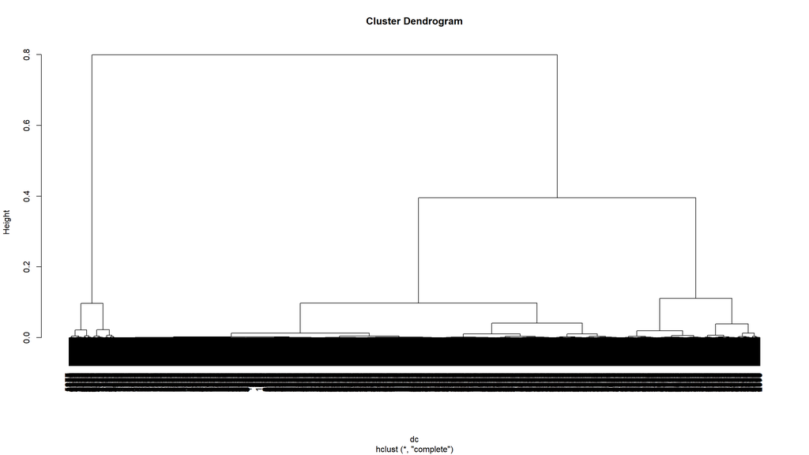

```r
dc = as.dist(1- cor(t(x)))
hc_cor_cmpl = hclust(dc, method = 'complete')
plot(hc_cor_cmpl)
```

To demonstrate how to handle comparisons across multiple clusters, I will split the clustering with three groups. For one versus one comparisons, we will have $3\choose{2}$ $=\frac{3(3-1)}{2} = 3$ comparisons. For one versus all comparisons, we will have $3$.

In what I show below, we will simply have the code print the output. However, there is nothing stopping us from creating an object to store the results. A small amount of setup first. All tests will be unconditional.

**How would you modify the code below to produce conditional comparisons?**

```r
y = cutree(hc_cor_cmpl, 3)
table(y)
```

```
## y
##    1    2    3
##  475 5175 1419
```

```r
df = data.frame(group = y, sx)

n = length(unique(y))
P = ncol(sx)
vars = colnames(sx)
```

### One Versus One

```r
for(i in 1:(n-1)){
  J = (i+1):n
  for(j in J){
    temp = df[df$group %in% c(i,j), ]
    for(p in 2:(P+1)){
      t = t.test(temp[,p] ~ temp$group)
      cat('Variable:', vars[(p-1)], '    Group', i, 'mean:', round(t$estimate[1],2), '    Group', j, 'mean:', round(t$estimate[2],2), '    p-value', signif(t$p.value,2), '\n')
    }
  }
}
```

```
## Variable: educ     Group 1 mean: 0.23     Group 2 mean: -0.06     p-value 1.6e-11
## Variable: wkswork1     Group 1 mean: 0.11     Group 2 mean: -0.03     p-value 0.00017
## Variable: uhrswork     Group 1 mean: 0.19     Group 2 mean: -0.04     p-value 1.4e-06
## Variable: incwage     Group 1 mean: 1.67     Group 2 mean: -0.26     p-value 3.1e-284
## Variable: trantime     Group 1 mean: 0.04     Group 2 mean: 0.01     p-value 0.62
## Variable: city_pop     Group 1 mean: -0.62     Group 2 mean: 0.22     p-value 0
## Variable: children     Group 1 mean: 0.11     Group 2 mean: -0.05     p-value 0.0011
## Variable: female     Group 1 mean: -0.31     Group 2 mean: 0.07     p-value 1.8e-25
## Variable: married     Group 1 mean: 0.27     Group 2 mean: -0.08     p-value 9.8e-18
## Variable: black     Group 1 mean: -0.13     Group 2 mean: 0.04     p-value 5.6e-08
## Variable: asian     Group 1 mean: 0.03     Group 2 mean: 0.01     p-value 0.71
## Variable: educ     Group 1 mean: 0.23     Group 3 mean: 0.15     p-value 0.074
## Variable: wkswork1     Group 1 mean: 0.11     Group 3 mean: 0.06     p-value 0.21
## Variable: uhrswork     Group 1 mean: 0.19     Group 3 mean: 0.09     p-value 0.049
## Variable: incwage     Group 1 mean: 1.67     Group 3 mean: 0.38     p-value 2.6e-185
## Variable: trantime     Group 1 mean: 0.04     Group 3 mean: -0.05     p-value 0.17
## Variable: city_pop     Group 1 mean: -0.62     Group 3 mean: -0.58     p-value 6.8e-77
## Variable: children     Group 1 mean: 0.11     Group 3 mean: 0.15     p-value 0.41
## Variable: female     Group 1 mean: -0.31     Group 3 mean: -0.17     p-value 0.00034
## Variable: married     Group 1 mean: 0.27     Group 3 mean: 0.19     p-value 0.072
## Variable: black     Group 1 mean: -0.13     Group 3 mean: -0.1     p-value 0.29
## Variable: asian     Group 1 mean: 0.03     Group 3 mean: -0.04     p-value 0.19
## Variable: educ     Group 2 mean: -0.06     Group 3 mean: 0.15     p-value 6.2e-14
## Variable: wkswork1     Group 2 mean: -0.03     Group 3 mean: 0.06     p-value 0.0016
## Variable: uhrswork     Group 2 mean: -0.04     Group 3 mean: 0.09     p-value 6.3e-06
## Variable: incwage     Group 2 mean: -0.26     Group 3 mean: 0.38     p-value 2e-102
## Variable: trantime     Group 2 mean: 0.01     Group 3 mean: -0.05     p-value 0.057
## Variable: city_pop     Group 2 mean: 0.22     Group 3 mean: -0.58     p-value 0
## Variable: children     Group 2 mean: -0.05     Group 3 mean: 0.15     p-value 2e-11
## Variable: female     Group 2 mean: 0.07     Group 3 mean: -0.17     p-value 1.4e-18
## Variable: married     Group 2 mean: -0.08     Group 3 mean: 0.19     p-value 8.5e-23
## Variable: black     Group 2 mean: 0.04     Group 3 mean: -0.1     p-value 2.5e-08
## Variable: asian     Group 2 mean: 0.01     Group 3 mean: -0.04     p-value 0.064
```

### One Versus All

```r
for(i in 1:n){
  temp = df
  j = which(temp$group != i)
  temp$group[j] = i+1
  for(p in 2:(P+1)){
    t = t.test(temp[,p] ~ temp$group)
    cat('Variable:', vars[(p-1)], '    Group', i, 'mean:', round(t$estimate[1],2), '    Remaining groups mean:', round(t$estimate[2],2), '    p-value', signif(t$p.value,2), '\n')
  }
}
```

```
## Variable: educ     Group 1 mean: 0.23     Remaining groups mean: -0.02     p-value 6.5e-09
## Variable: wkswork1     Group 1 mean: 0.11     Remaining groups mean: -0.01     p-value 0.00084
## Variable: uhrswork     Group 1 mean: 0.19     Remaining groups mean: -0.01     p-value 1.8e-05
## Variable: incwage     Group 1 mean: 1.67     Remaining groups mean: -0.12     p-value 7.9e-264
## Variable: trantime     Group 1 mean: 0.04     Remaining groups mean: 0     p-value 0.48
## Variable: city_pop     Group 1 mean: -0.62     Remaining groups mean: 0.04     p-value 0
## Variable: children     Group 1 mean: 0.11     Remaining groups mean: -0.01     p-value 0.016
## Variable: female     Group 1 mean: -0.31     Remaining groups mean: 0.02     p-value 1.8e-20
## Variable: married     Group 1 mean: 0.27     Remaining groups mean: -0.02     p-value 2.5e-13
## Variable: black     Group 1 mean: -0.13     Remaining groups mean: 0.01     p-value 3e-06
## Variable: asian     Group 1 mean: 0.03     Remaining groups mean: 0     p-value 0.55
## Variable: educ     Group 2 mean: -0.06     Remaining groups mean: 0.17     p-value 3.9e-20
## Variable: wkswork1     Group 2 mean: -0.03     Remaining groups mean: 0.07     p-value 4.7e-05
## Variable: uhrswork     Group 2 mean: -0.04     Remaining groups mean: 0.12     p-value 2.4e-09
## Variable: incwage     Group 2 mean: -0.26     Remaining groups mean: 0.7     p-value 1.6e-233
## Variable: trantime     Group 2 mean: 0.01     Remaining groups mean: -0.03     p-value 0.2
## Variable: city_pop     Group 2 mean: 0.22     Remaining groups mean: -0.59     p-value 0
## Variable: children     Group 2 mean: -0.05     Remaining groups mean: 0.14     p-value 1.4e-12
## Variable: female     Group 2 mean: 0.07     Remaining groups mean: -0.2     p-value 2.4e-30
## Variable: married     Group 2 mean: -0.08     Remaining groups mean: 0.21     p-value 3.9e-32
## Variable: black     Group 2 mean: 0.04     Remaining groups mean: -0.11     p-value 3.8e-11
## Variable: asian     Group 2 mean: 0.01     Remaining groups mean: -0.03     p-value 0.19
## Variable: educ     Group 3 mean: 0.15     Remaining groups mean: -0.04     p-value 1.9e-11
## Variable: wkswork1     Group 3 mean: 0.06     Remaining groups mean: -0.01     p-value 0.0051
## Variable: uhrswork     Group 3 mean: 0.09     Remaining groups mean: -0.02     p-value 0.00011
## Variable: incwage     Group 3 mean: 0.38     Remaining groups mean: -0.09     p-value 3.6e-58
## Variable: trantime     Group 3 mean: -0.05     Remaining groups mean: 0.01     p-value 0.046
## Variable: city_pop     Group 3 mean: -0.58     Remaining groups mean: 0.15     p-value 0
## Variable: children     Group 3 mean: 0.15     Remaining groups mean: -0.04     p-value 2.6e-10
## Variable: female     Group 3 mean: -0.17     Remaining groups mean: 0.04     p-value 8.3e-15
## Variable: married     Group 3 mean: 0.19     Remaining groups mean: -0.05     p-value 5.1e-19
## Variable: black     Group 3 mean: -0.1     Remaining groups mean: 0.02     p-value 3.2e-07
## Variable: asian     Group 3 mean: -0.04     Remaining groups mean: 0.01     p-value 0.054
```